# Fisheries status as a pressure

This notebook turns a finished fisheries (FIS) score table into a pressure table. The score is already on a 0–100 scale, with a high score meaning a healthier fishery. A pressure runs the other way: 0 is no stress and 1 is the top of the scale. The conversion is

`pressure = round(1 - FIS_Score * 0.01, 2)`.

A score of 100 becomes a pressure of 0. A score of 0 would become a pressure of 1. The saved file has one row per OHI region and year, with columns `rgn_id`, `year`, and `pressure`.

To use a newly generated score file, change `scores_path` below and knit again. The new file needs the columns `OHI_region_est`, `year`, and `FIS_Score`. The pressure file is rewritten in this folder as `FIS_pressure.csv`.

Rows whose region is missing are left out. In the current score file that label is the text `NA`, which is not one of the nine OHI regions. `read_csv()` reads that text as a missing value.

```r
library(tidyverse)
library(knitr)

knitr::opts_chunk$set(message = FALSE, warning = FALSE)

# Score export. Change this path when a new file is generated.
scores_path <- "/home/ferrer/ohi_goc_prep/FP/v2026/FP_Scores_1.1/FIS_Scores_1.1/copy_FIS_Scores_1.0_df_Jun052026.csv"

# This account can read the score export above and cannot write in that
# folder, so the pressure file is saved here, beside this notebook.
out_dir <- "/home/frazier/ohi_goc_prep/FP/v2026/FP_Scores_1.1/FIS_Scores_1.1"
pressure_file <- "FIS_pressure.csv"

rgn_colors <- c(
  "Region 1" = "#C03729",
  "Region 2" = "#E68C7C",
  "Region 3" = "#FC8F24",
  "Region 4" = "#dcaa38",
  "Region 5" = "#cbd2a0",
  "Region 6" = "#98a25a",
  "Region 7" = "#747428",
  "Region 8" = "#627391",
  "Region 9" = "#8d61a9"
)
```

## 1. Read the score export

```r
scores_raw <- read_csv(scores_path, show_col_types = FALSE)

needed <- c("OHI_region_est", "year", "FIS_Score")
stopifnot(all(needed %in% names(scores_raw)))

# read_csv() turns the text "NA" into a missing region. Count those rows
# before they are removed so a future file that loses a real region is obvious.
n_unassigned <- sum(is.na(scores_raw$OHI_region_est))

scores <- scores_raw %>%
  filter(!is.na(OHI_region_est)) %>%
  transmute(
    rgn_id = str_replace(OHI_region_est, "^region_", "Region_"),
    year = as.integer(year),
    score = FIS_Score
  )

cat("Score file:", scores_path, "\n")
```

```
## Score file: /home/ferrer/ohi_goc_prep/FP/v2026/FP_Scores_1.1/FIS_Scores_1.1/copy_FIS_Scores_1.0_df_Jun052026.csv
```

```r
cat("Rows read:", nrow(scores_raw), "\n")
```

```
## Rows read: 70
```

```r
cat("Rows with no OHI region, set aside:", n_unassigned, "\n")
```

```
## Rows with no OHI region, set aside: 7
```

```r
cat("Regions kept:", paste(sort(unique(scores$rgn_id)), collapse = ", "), "\n")
```

```
## Regions kept: Region_1, Region_2, Region_3, Region_4, Region_5, Region_6, Region_7, Region_8, Region_9
```

```r
cat("Years:", paste(sort(unique(scores$year)), collapse = ", "), "\n")
```

```
## Years: 2018, 2019, 2020, 2021, 2022, 2023, 2024
```

The region id in the score file is `region_1`. The other pressure tables use `Region_1`, so the prefix is rewritten here. Each region-year must appear once, and each score must sit on the 0–100 scale the conversion assumes.

```r
stopifnot(all(str_detect(scores$rgn_id, "^Region_[1-9]$")))
stopifnot(!anyDuplicated(scores[c("rgn_id", "year")]))
stopifnot(all(scores$score >= 0), all(scores$score <= 100))
stopifnot(n_distinct(scores$rgn_id) == 9)
```

## 2. Pressure

Subtracting the score, as a fraction of 100, from 1 reverses the scale. Rounding to two decimal places matches the other recent pressure tables.

```r
pressure <- scores %>%
  mutate(pressure = round(1 - score * 0.01, 2)) %>%
  select(rgn_id, year, pressure) %>%
  arrange(year, rgn_id)

stopifnot(nrow(pressure) == 9 * n_distinct(pressure$year))
stopifnot(all(pressure$pressure >= 0), all(pressure$pressure <= 1))

pressure_path <- file.path(out_dir, pressure_file)
write_csv(pressure, pressure_path)

cat("Wrote", pressure_path, "\n")
```

```
## Wrote /home/frazier/ohi_goc_prep/FP/v2026/FP_Scores_1.1/FIS_Scores_1.1/FIS_pressure.csv
```

```r
cat("Rows:", nrow(pressure), "\n")
```

```
## Rows: 63
```

```r
kable(
  pressure,
  digits = 2,
  caption = "Fisheries pressure by region and year"
)
```

Fisheries pressure by region and year

| rgn_id | year | pressure |
| --- | --- | --- |
| Region_1 | 2018 | 0.06 |
| Region_2 | 2018 | 0.10 |
| Region_3 | 2018 | 0.12 |
| Region_4 | 2018 | 0.11 |
| Region_5 | 2018 | 0.14 |
| Region_6 | 2018 | 0.09 |
| Region_7 | 2018 | 0.17 |
| Region_8 | 2018 | 0.02 |
| Region_9 | 2018 | 0.20 |
| Region_1 | 2019 | 0.03 |
| Region_2 | 2019 | 0.10 |
| Region_3 | 2019 | 0.08 |
| Region_4 | 2019 | 0.07 |
| Region_5 | 2019 | 0.03 |
| Region_6 | 2019 | 0.07 |
| Region_7 | 2019 | 0.21 |
| Region_8 | 2019 | 0.04 |
| Region_9 | 2019 | 0.11 |
| Region_1 | 2020 | 0.05 |
| Region_2 | 2020 | 0.07 |
| Region_3 | 2020 | 0.13 |
| Region_4 | 2020 | 0.10 |
| Region_5 | 2020 | 0.19 |
| Region_6 | 2020 | 0.11 |
| Region_7 | 2020 | 0.22 |
| Region_8 | 2020 | 0.07 |
| Region_9 | 2020 | 0.06 |
| Region_1 | 2021 | 0.13 |
| Region_2 | 2021 | 0.07 |
| Region_3 | 2021 | 0.10 |
| Region_4 | 2021 | 0.09 |
| Region_5 | 2021 | 0.17 |
| Region_6 | 2021 | 0.09 |
| Region_7 | 2021 | 0.11 |
| Region_8 | 2021 | 0.08 |
| Region_9 | 2021 | 0.05 |
| Region_1 | 2022 | 0.28 |
| Region_2 | 2022 | 0.09 |
| Region_3 | 2022 | 0.19 |
| Region_4 | 2022 | 0.14 |
| Region_5 | 2022 | 0.15 |
| Region_6 | 2022 | 0.09 |
| Region_7 | 2022 | 0.24 |
| Region_8 | 2022 | 0.08 |
| Region_9 | 2022 | 0.05 |
| Region_1 | 2023 | 0.30 |
| Region_2 | 2023 | 0.08 |
| Region_3 | 2023 | 0.26 |
| Region_4 | 2023 | 0.15 |
| Region_5 | 2023 | 0.37 |
| Region_6 | 2023 | 0.08 |
| Region_7 | 2023 | 0.24 |
| Region_8 | 2023 | 0.08 |
| Region_9 | 2023 | 0.04 |
| Region_1 | 2024 | 0.35 |
| Region_2 | 2024 | 0.14 |
| Region_3 | 2024 | 0.30 |
| Region_4 | 2024 | 0.18 |
| Region_5 | 2024 | 0.15 |
| Region_6 | 2024 | 0.11 |
| Region_7 | 2024 | 0.25 |
| Region_8 | 2024 | 0.07 |
| Region_9 | 2024 | 0.06 |

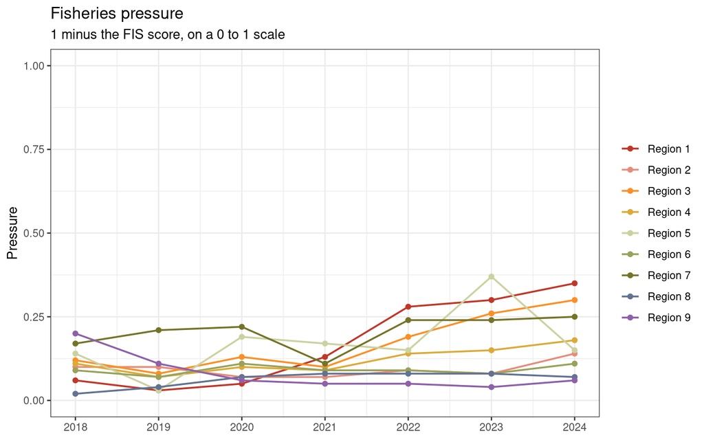

```r
pressure %>%
  mutate(region_label = str_replace(rgn_id, "_", " ")) %>%
  ggplot(aes(year, pressure, color = region_label)) +
  geom_line(linewidth = 0.7) +
  geom_point(size = 1.6) +
  scale_color_manual(values = rgn_colors, name = NULL) +
  scale_x_continuous(breaks = sort(unique(pressure$year))) +
  scale_y_continuous(limits = c(0, 1)) +
  labs(
    title = "Fisheries pressure",
    subtitle = "1 minus the FIS score, on a 0 to 1 scale",
    x = NULL,
    y = "Pressure"
  ) +
  theme_bw() +
  theme(legend.position = "right")
```